# Visualising Diffusion on FB100+FB1000-Networks

This notebook is to visualise the IC Diffusion spread on the FB100-net and FB1000-net graphs. This is done in order to observe the nodes/graph-components in the context of Infection-Spread.

```python
import random
import networkx as nx
import time
import os
import numpy as np
import pickle
import json
import ast
from pickle import load
from matplotlib.pylab import plt

from math import floor

# import tensorflow as tf
# from tensorflow.keras.models import Model
# from tensorflow.keras.layers import Input, Dropout, Dense
# from tensorflow.keras import Sequential
# from keras.optimizers import Adam
# from keras.optimizers import SGD
# from tensorflow.keras.regularizers import l2

from tqdm import tqdm
```

### Graph-Network Environment Setup and Node-Properties (FB100-network)

Setting up the the 100-node FB network and checking it's properties. This is before any edge-weights are initialised.

```python
network = 'facebook_network100.txt'
base_filename = os.path.splitext(os.path.basename(network))[0]

with open(network) as f:
    G = nx.Graph([line.split()[:2] for line in f])
print(G)
print(nx.is_connected(G))
print(nx.is_directed(G))

# Graph = nx.read_edgelist(network, create_using=nx.Graph(), nodetype=int)
# print(Graph)
# print(nx.is_connected(Graph))
# print(nx.is_directed(Graph))
# print(len(G.nodes()))
```

```
Graph with 100 nodes and 332 edges
True
False
```

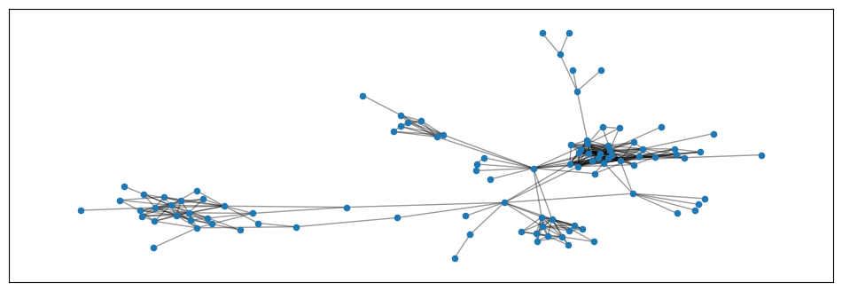

```python
degree_sequence = sorted((d for n, d in G.degree()), reverse=True)
dmax = max(degree_sequence)

fig = plt.figure(figsize=(12, 4))

Gcc = G.subgraph(sorted(nx.connected_components(G), key=len, reverse=True)[0])
pos = nx.spring_layout(Gcc, seed=10396953)
nx.draw_networkx_nodes(Gcc, pos, node_size=20)
nx.draw_networkx_edges(Gcc, pos, alpha=0.4)
```

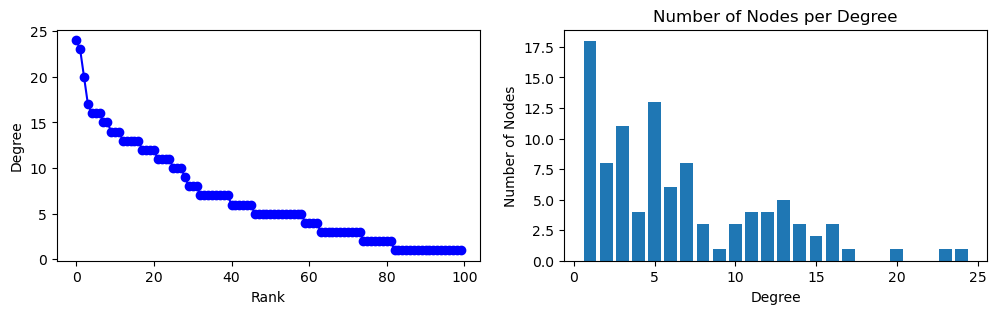

```python
f = plt.figure(figsize = (12, 3))

ax = plt.subplot(121)
ax.plot(degree_sequence, "b-", marker="o")
ax.set_ylabel("Degree")
ax.set_xlabel("Rank")

ax = plt.subplot(122)
ax.bar(*np.unique(degree_sequence, return_counts=True))
ax.set_title("Number of Nodes per Degree")
ax.set_xlabel("Degree")
ax.set_ylabel("Number of Nodes")

fig.tight_layout()
plt.show()
```

Both from the number of nodes with associated degree, and the visualisation of the FB-Network, we can identify that about 18 nodes out of a 100 are only connected to the rest of the graph by a single edge, while the top 4 highest-connected nodes have 24, 23, 20, and 17 neighbours.

```python
for n in G.nodes():
    G.nodes[n]['degree'] = G.degree(n)

#print(np.array(G.nodes('degree')))

node_array = np.array(G.nodes())
degree_array = np.zeros(len(G.nodes()))

for n in range(len(G.nodes())):
    degree_array[n] = np.array(G.nodes('degree'))[n, 1]
print(degree_array)
```

```
[12. 15. 10.  4. 10.  5.  5.  8. 13.  7.  5.  8.  5. 12. 23.  7.  2. 20.
  1.  3. 16.  3.  2. 24.  7. 16.  3. 16. 11.  8.  5.  5.  5.  3. 14. 13.
 13. 15. 14. 10.  7. 17.  6.  3.  2.  5.  2. 11. 13.  7.  9. 12. 14. 12.
 13.  1.  2.  6. 11.  4. 11.  4.  6.  6.  7.  5.  1.  2.  3.  1.  1.  5.
  5.  3.  2.  5.  2.  6.  7.  5.  7.  1.  1.  1.  3.  3.  1.  4.  1.  1.
  1.  1.  1.  3.  3.  1.  1.  1.  6.  1.]
```

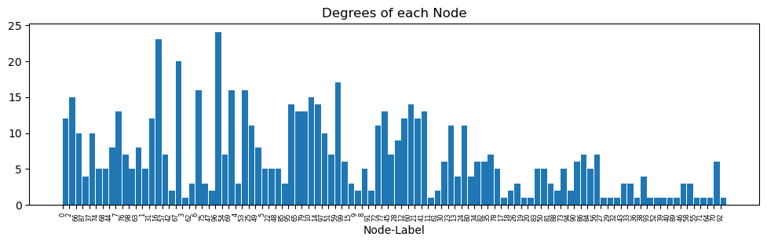

```python
plt.figure(figsize=(12,3))
#plt.hist(G.nodes('degree'), bins = len(G.nodes()))

plt.bar(node_array, degree_array,  align='edge', width=0.9)
plt.title('Degrees of each Node')
plt.xlabel('Node-Label')
plt.xticks(rotation=90, fontsize=6)

plt.show()
```

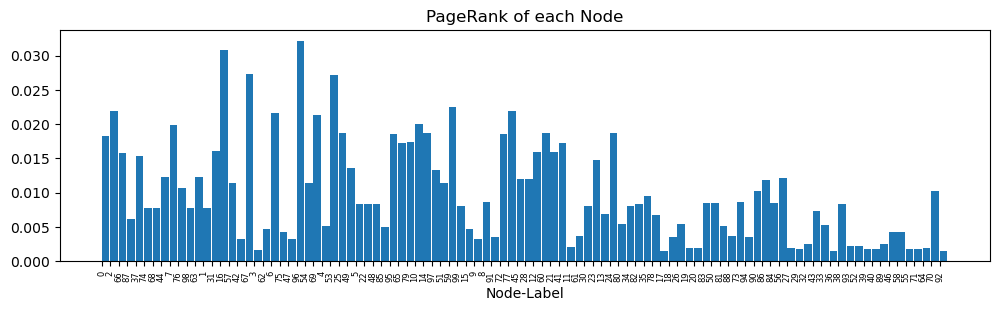

```python
pagerank = nx.pagerank(G, alpha = 0.98) # PageRank damping as close to 1 as possible to eliminate any randomness
pagerank_array = np.array([*pagerank.values()], dtype=object)

plt.figure(figsize=(12,3))

plt.bar(node_array, pagerank_array,  align='edge', width=0.9)
plt.title('PageRank of each Node')
plt.xlabel('Node-Label')
plt.xticks(rotation=90, fontsize=6)

plt.show()
```

Note that PageRank and Degree distributions are similar but not equivalent. This is because the undirected graph-network is not regular.

This PageRank alg assumes convergence within 100 iterations and a 0.02 probability of selecting a link to any random node in the graph whether or not it is connected by an edge.

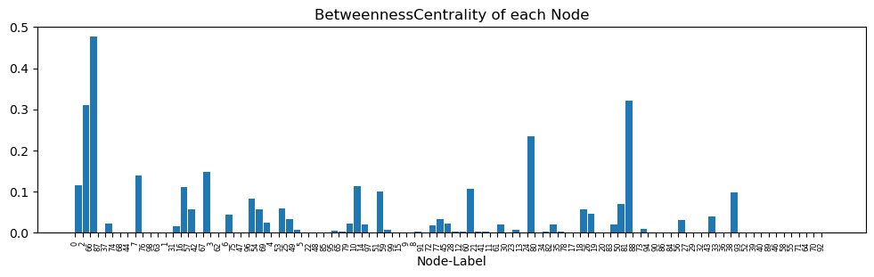

```python
bet_cent = nx.betweenness_centrality(G)
bet_cent_array = np.array([*bet_cent.values()], dtype=object)

plt.figure(figsize=(12,3))

plt.bar(node_array, bet_cent_array,  align='edge', width=0.9)
plt.title('BetweennessCentrality of each Node')
plt.xlabel('Node-Label')
plt.xticks(rotation=90, fontsize=6)

plt.show()
```

From the visualisation and node-edge properties of the network, select and observe properties of a node to be intially-infected:

```python
def v_initialnode(initial_infected):

    print(f'Node {initial_infected}:')
    print(f'Degree = {G.degree(initial_infected)}')
    print(f'PageRank = {pagerank[initial_infected]}')
    print(f'BetweennessCentrality = {bet_cent[initial_infected]}')

    nodeindex = int(np.where(node_array == initial_infected)[0])

    blue = 'b'

    colormap = []
    sizemap = []

    for i in range(len(G.nodes())):
        colormap.append(blue)
        sizemap.append(5)


    colormap[nodeindex] = 'r'
    sizemap[nodeindex] = 50

    fig = plt.figure(figsize=(12, 4))

    Gcc = G.subgraph(sorted(nx.connected_components(G), key=len, reverse=True)[0])
    pos = nx.spring_layout(Gcc, seed=10396953)
    nx.draw_networkx_nodes(Gcc, pos, node_color=colormap,node_size=sizemap)
    nx.draw_networkx_edges(Gcc, pos, alpha=0.4)
```

"Easy" Node for IMP purposes:

```
Node 33:
Degree = 3
PageRank = 0.0052190710214144774
BetweennessCentrality = 6.871435442864013e-05
```

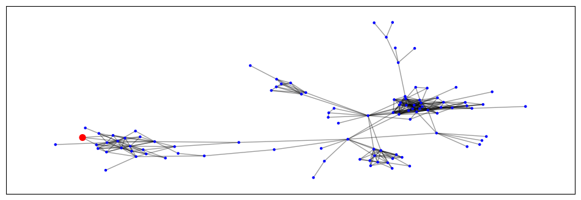

```python
v_initialnode('33')
```

Highest Degree/PageRank:

```
Node 96:
Degree = 24
PageRank = 0.0321246648195588
BetweennessCentrality = 0.08327768098821758
```

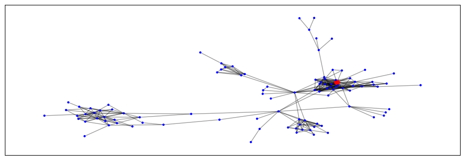

```python
v_initialnode('96')
```

Highest BetweennessCentrality:

```
Node 66:
Degree = 10
PageRank = 0.01587213874511193
BetweennessCentrality = 0.47675704230674054
```

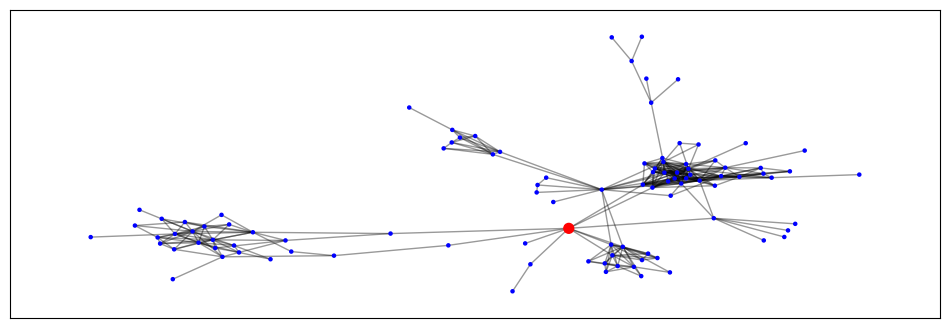

```python
v_initialnode('66')
```

```
Node 2:
Degree = 15
PageRank = 0.02200207057092917
BetweennessCentrality = 0.3114003865628825
```

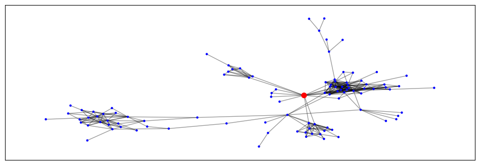

```python
v_initialnode('2')
```